# Online Shoppers Intention

### Smote

```r
trainSet$Revenue<- as.factor(trainSet$Revenue)
smoted_data <- DMwR::SMOTE(Revenue ~ ., trainSet, perc.over=100)
smoted_data$Revenue<- as.numeric(smoted_data$Revenue)

prop.table(table(smoted_data$Revenue))
```

```
##
##   1   2
## 0.5 0.5
```

- Now classes are balance, let’s apply same grid search and compare results

```r
param <-  expand.grid(nrounds = c(50,100),
                      max_depth = c(5, 6, 10, 12),
                      eta = c(0.3, 0.1, 0.03), gamma = c(0.5, 1),
                      colsample_bytree = c(0.8, 0.9, 1), min_child_weight = 1,
                      subsample = c(0.5,0.8, 1))
set.seed(33)
xgb_trcontrol = trainControl(
    method = "cv",
    number = 5,
    verboseIter = TRUE,
    returnData = FALSE,
    returnResamp = "all",              # save losses across all models
    classProbs = TRUE,                 # set to TRUE for LogLoss to be computed
    allowParallel = TRUE,
    summaryFunction = mnLogLoss,
    preProcOptions = "scale",  #scale numeric variables
    seeds = 33)
set.seed(33)
smote_fit.xgb <- train(x = as.matrix(select(smoted_data,-Revenue)),
                       y = factor(smoted_data$Revenue, labels = c("first_class", "second_class")),
                       method="xgbTree",
                       metric="logLoss", trControl=xgb_trcontrol ,tuneGrid=param)
```

### Evaluation XGBoost and XGBoost Smote

```r
eval <- predict(smote_fit.xgb, testSet,type = "prob")[["second_class"]] > 0.5

confusion_matrix_xgb1 <- cbind(testSet$Revenue,eval) %>%
    data.frame() %>%
    table() %>% confusionMatrix()

models <- c("XGB", "XGB Smote")

error_class_1 <- round(c(confusion_matrix_xgb0$table[2,1] /
                             (confusion_matrix_xgb0$table[2,1] + confusion_matrix_xgb0$table[2,2]),
                         confusion_matrix_xgb1$table[2,1] /
                             (confusion_matrix_xgb1$table[2,1] + confusion_matrix_xgb1$table[2,2])),4)

logloss_ <- round(c(logLoss(testSet$Revenue, predict(fit.xgb, testSet,type = "prob")[["second_class"]]),
                    logLoss(testSet$Revenue, predict(smote_fit.xgb, testSet,type = "prob")[["second_class"]])),4)

auc_ <- round(c(auc(testSet$Revenue, predict(fit.xgb, testSet,type = "prob")[["second_class"]]),
                auc(testSet$Revenue, predict(smote_fit.xgb, testSet,type = "prob")[["second_class"]])),4)


eval_models_xgb <- data.frame(models, auc_, logloss_, error_class_1, stringsAsFactors = F) %>%
    arrange(desc(auc_))
eval_models_xgb
```

```
##      models   auc_ logloss_ error_class_1
## 1       XGB 0.9562   0.1880        0.3701
## 2 XGB Smote 0.9550   0.2399        0.1470
```

- AUC is basically the same, logloss does not improve, but we have managed to reduce the classification error in our target class by more than half, so we will use XGBoost with smote
- Let’s see which variables are the most important in our model

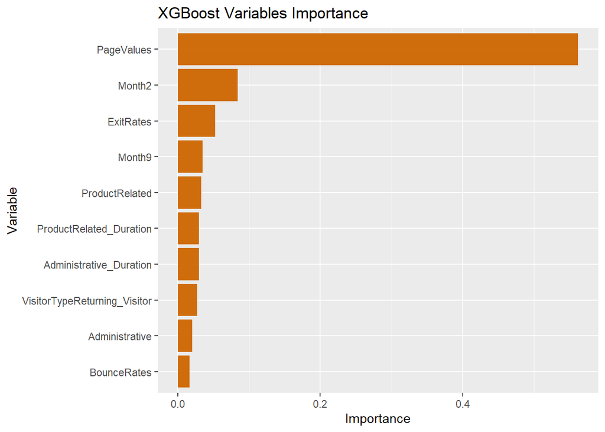

```r
xgb_varImp <- varImp(smote_fit.xgb, scale = F)$importance
xgb_varImp <- rownames_to_column(xgb_varImp,"Variables")
ggplot(head(xgb_varImp,10), aes(x= Overall, y=fct_reorder(Variables, Overall))) +
    geom_col() +
        labs(x = "Importance",
             y = "Variable",
             title = "XGBoost Variables Importance")
```

- As we expected after observing the distributions, by far the most important variable is **Page Value**.

### Evaluation XGBoost Smote with plots

- Plots by Lares packages

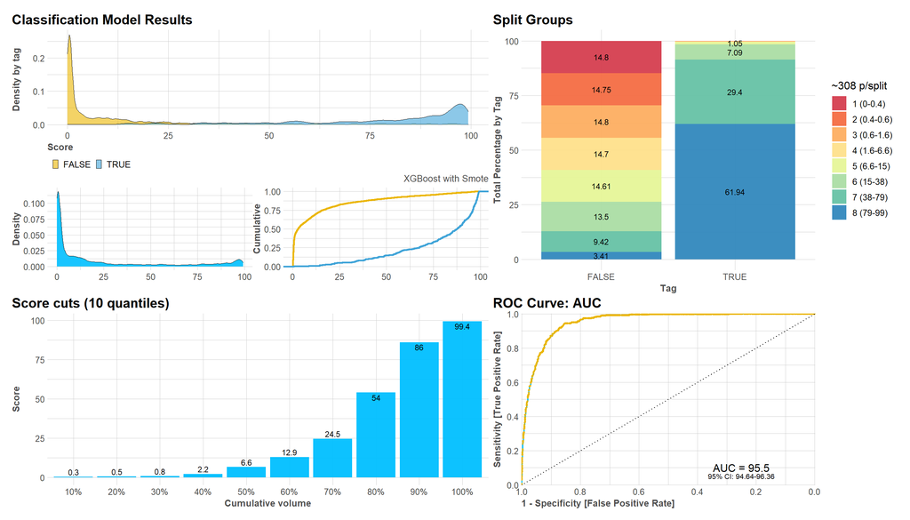

```r
mplot_full(tag = testSet$Revenue,
           score =predict(smote_fit.xgb, testSet,type = "prob")[["second_class"]] , model_name = "XGBoost with Smote")
```

- If any of these graphics are not familiar to you, you can get more information at https://datascienceplus.com/machine-learning-results-one-plot-to-rule-them-all/
- Confusion matrix

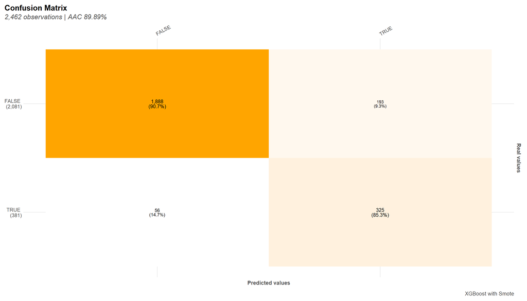

```r
mplot_conf(tag = testSet$Revenue,
           score =predict(smote_fit.xgb, testSet,type = "prob")[["second_class"]],model_name = "XGBoost with Smote")
```

## Business evaluation

### Let’s answer some business questions.

- When we apply the model and select the best X deciles, what % of the actual target class observations can we expect to target?

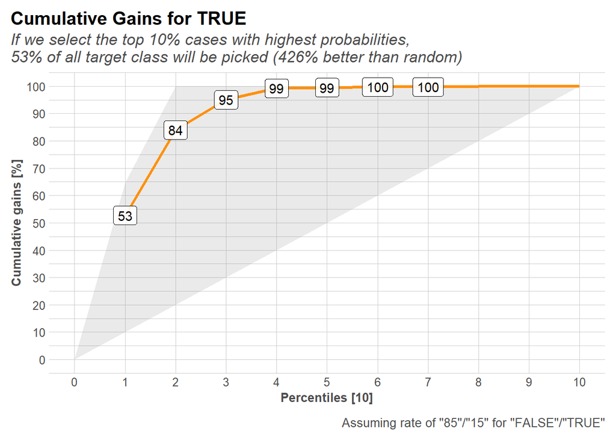

```r
mplot_gain(tag = testSet$Revenue,
           score =predict(smote_fit.xgb, testSet,type = "prob")[["second_class"]])
```

- When we select the **10%** with the highest probability according to XGBoost, this selection contains **53%** of all users who make a purchase in test data.
- When we apply the model and select up until decile X, what is the expected % of target class observations in the selection?

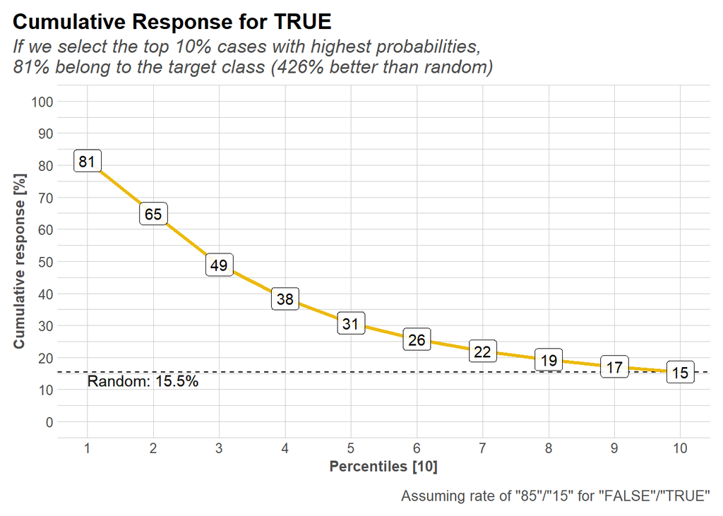

```r
mplot_response(tag = testSet$Revenue,
           score =predict(smote_fit.xgb, testSet,type = "prob")[["second_class"]])
```

- When we select deciles 1 until 3 according to model XGBoost in test data the % of users who make a purchase in the selection is **49%**.

**Thanks for your interest!!**